# Congress

POLS 2311: Government of the United States

## Agenda

- Congress vs. Parliament, and Who Serves
- The Framers’ Design: Federalist 55 and 62
- Congressional Powers
- Congressional Elections and Redistricting
- Representation in the Senate
- Representation
- Congressional Organization
- Electoral Incentives
- Performance and Reform

## Congressional Approval

[figure not shown]

## Congressional Reelection Rates

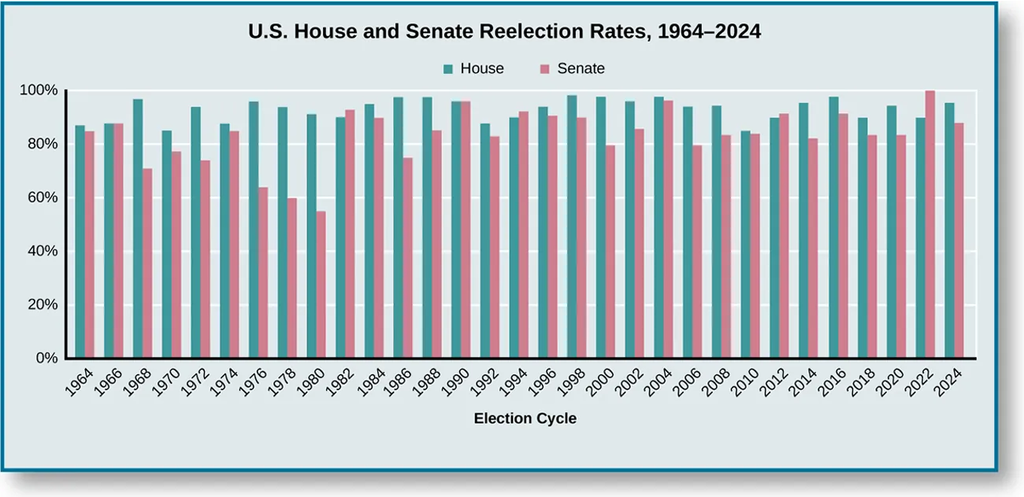

## The Congress

- Congress heads the legislative branch of government, comprised of the *House of Representatives* and the *Senate*
- *Bicameralism*: The practice of having two legislative chambers
- Important functions of Congress:
  - *Lawmaking*
  - Represent the views of constituents
  - Be of service to constituents in dealings with the national government
  - Provide oversight of the actions of the president and his administration

## Congress versus Parliament

**Congress**

- Runs for the party nomination, but voters ultimately decide
- Members have individual, independent power
- Robust staff and resources

**Parliament**

- Selected by the political party to be placed on the ballot
- Power is mostly group-based, rather than individual
- Fewer resources and staff

# The Framers’ Design

## The Congress

### Federalist No. 51

> *In republican government, the legislative authority necessarily predominates*

## The Congress

- Designed to be a *deliberative* body
- Represents various interests
  - States (Senate)
  - The People (House)
- Balancing competing interests
  - Small states and big states

## How Large Should the House Be?

### Federalist No. 55

- Anti-Federalists attacked the proposed House of only **65 members**. They said it would:
  - Be too small to be trusted with the public interest
  - Not know the local circumstances of its many constituents
  - Be drawn from an elite aiming at “a permanent elevation of the few on the depression of the many”
  - Grow more disproportionate as the population grew
- Madison’s reply: “No political problem is less susceptible of a precise solution”

## Federalist No. 55

### A Floor and a Ceiling

- **Too small**: risks “too easy a combination for improper purposes” and loses “free consultation and discussion”
- **Too large**: produces “the confusion and intemperance of a multitude”
- 60–70 members are safer than 6 or 7, but 600–700 are not proportionally better
- At 6,000–7,000, “the whole reasoning ought to be reversed”
- The problem is **size itself**, not the character of the members

## Federalist No. 55

> *In all very numerous assemblies, of whatever character composed, passion never fails to wrest the sceptre from reason. Had every Athenian citizen been a Socrates, every Athenian assembly would still have been a mob*

## Why a Senate?

### Federalist No. 62

- The Articles of Confederation had a **single-chamber** legislature — the case for a second chamber had to be made
- **Higher qualifications** (age 30; nine years a citizen): the “senatorial trust” requires “greater extent of information and stability of character”
- **Selection by state legislatures**: favors “a select appointment” and gives state governments an “agency” in the federal government
- **Equal state representation**: a compromise between large and small states
- **Stability**: frequent turnover (“mutability in the public councils”) calls for “some stable institution in the government”

## Federalist No. 62

> *…the propensity of all single and numerous assemblies, to yield to the impulse of sudden and violent passions, and to be seduced by factious leaders into intemperate and pernicious resolutions*
- The cure: a body that is **less numerous** and holds office “by a tenure of considerable duration”

## Size, Tenure, and Deliberation

### Federalist 55 and 62 Together

|  | House | Senate |
| --- | --- | --- |
| Members | 435 | 100 |
| Term | 2 years | 6 years, staggered |
| Minimum age | 25 | 30 |
| Original selection | The people | State legislatures |
| Role for Madison | The popular branch | “Coolness,” “system,” “wisdom” |

- Deliberation depends on institutional design, not only on the character of members

# Congressional Powers

## The Powers of Congress

- *Enumerated powers*:
  - Power explicitly stated in the Constitution, Article I Section 8

Declare war

Impose taxes

Coin and regulate currency

Regulate foreign and interstate commerce

Raise and maintain an army and a navy

Maintain a post office

Make laws regulating the naturalization of immigrants

## The Powers of Congress

- *Implied powers*:
  - Powers not specifically detailed in the Constitution but inferred as necessary to achieve the objectives of the national government
  - *Elastic clause*:
    - *To make all Laws which shall be necessary and proper for carrying into Execution the foregoing Powers, and all other Powers vested by this Constitution in the Government of the United States, or in any Department or Officer thereof*
    - Allows Congress to pass all laws that are “necessary and proper” to carry out enumerated powers

## The Legislative Process

### Article I Section 7

[figure not shown]

## The Legislative Process

### Article I Section 7

[video not shown]

## The Legislative Process

### Article I Section 7

- Bill proposals
  - Only legislators can introduce bills
  - Beyond bills: simple, concurrent, and joint resolutions
- Bills referred to proper committee based on jurisdiction and party goals
- Committee action
  - Most bills not acted on in committee
  - Committees can choose to mark up bills for the floor

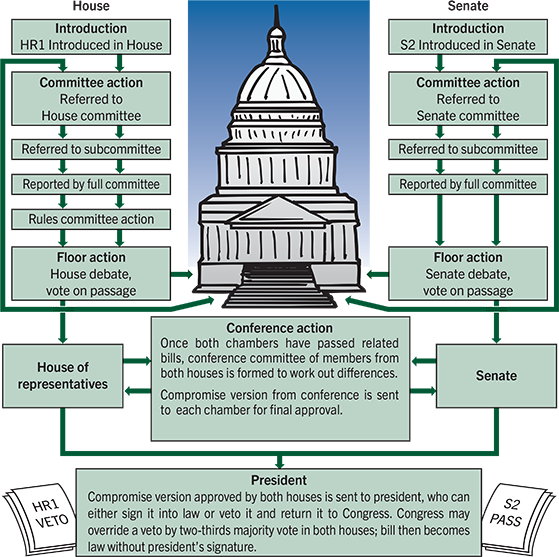

## The Legislative Process

### Article I Section 7

- House *Rules Committee* uses special rules to bring bills to the floor
  - Open rules
  - Closed rules
  - Restricted or modified rules
- Senate uses unanimous consent agreements to bring bills to floor
  - Unlimited debate enables the **filibuster**
  - Ending debate requires **cloture** — 60 votes
  - Empowers individual senators

## The Legislative Process

### Article I Section 7

- Enrolled bills sent to president
  - Sign, veto, or pocket veto
- House and Senate can override veto
  - Two-thirds majority in both chambers
- *Separation of powers system creates bias against action*

# Organization

## Party Control

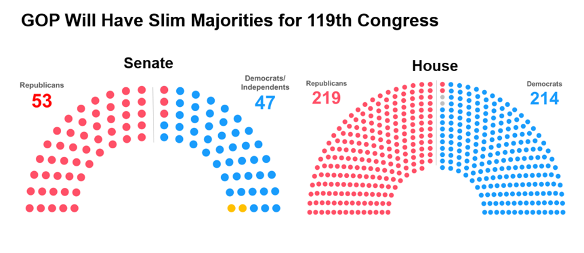

## Political Parties in Government

- Members organize themselves into party coalitions in the House and Senate called a caucus (Democrats) or a conference (Republicans)
- Members choose leadership (Speaker, Majority Leader, Minority Leader, Whips)
- Members empower party leaders to influence the agenda and manage legislation

## Congressional Caucuses

- Beyond party caucuses/conferences, members also form issue-based **caucuses**: *an association of congressional members created to advance a political ideology or a regional, ethnic, or economic interest*
- **Ideological**: e.g., Medicare for All Caucus
- **Regional**: e.g., Northeast-Midwest Congressional Coalition
- **Issue-specific**: e.g., Congressional Diabetes Caucus
- **Race/ethnicity-based**: e.g., Congressional Black Caucus

## Congressional Leadership: The House

- Speaker of the House
- The majority leader
- Minority leader
- Whips

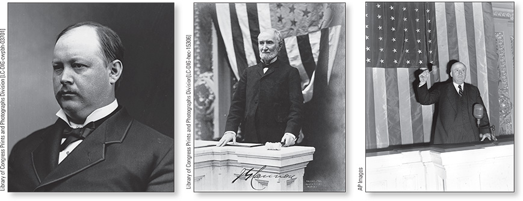

Three powerful Speakers of the House: Thomas B. Reed, Joseph G. Cannon, and Sam Rayburn.

## Congressional Leadership: The Senate

- The Vice-President
- President *pro tempore*: Longest severing member of the majority party
- **Majority leader**
- Minority leader
- Whips

## The Committee System

- Each committee focuses on and has *jurisdiction* within a particular area of policy
  - Allows for specialization and expertise in committees
  - Also allows self-selection for members
- Standing committees
- Special/select committees
- Joint committees
- Conference committees

## Standing Committees

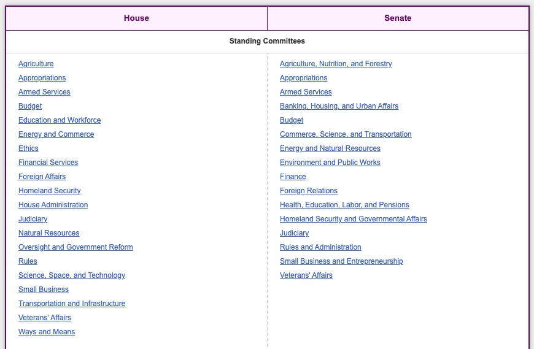

# Representation

## Representation Defined

- *An elected leader’s looking out for his or her constituents while carrying out the duties of the office*
- **Styles**
  - *Representational*: members believe they primarily represent their constituents
  - *Organizational*: members take cues from their colleagues and party
  - *Attitudinal*: members also often lead with their own viewpoints

## Forms of Representation

*Descriptive*: rooted in the racial, ethnic, socioeconomic, gender, and sexual identity of the representatives themselves

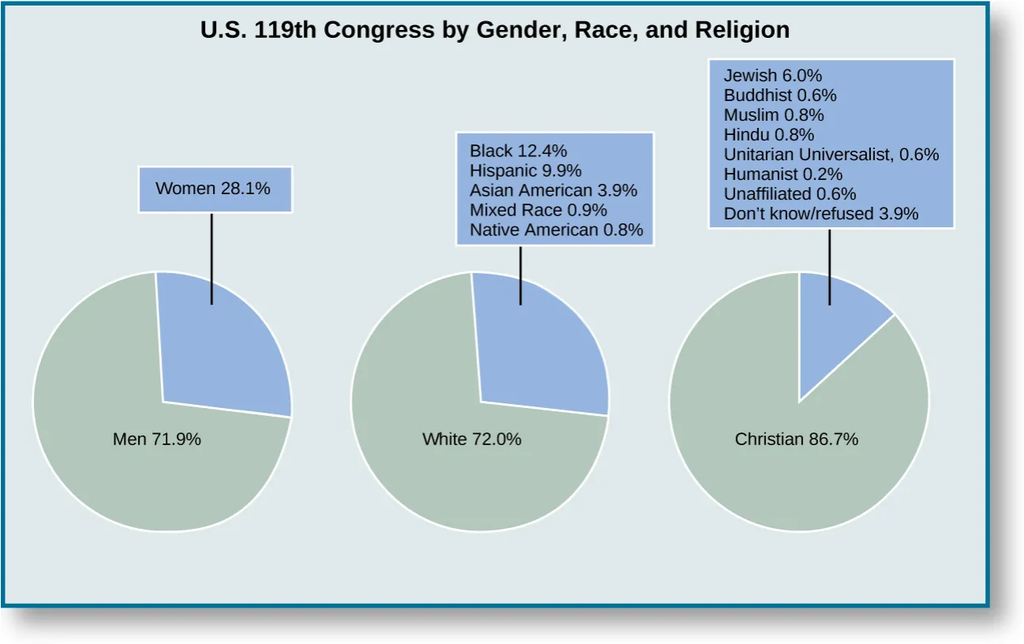

# Elections

## Congressional Elections

### The House of Representatives; Article I Section 2

- Elected every two years
- Must be 25 years old
- Based on population
  - *Three-fifths compromise*
  - Originally 1 for every 30,000; now ~800,000
  - Capped at 435 members in 1929
- States decide district boundaries
- **Single member districts; plurality of votes**

## Congressional Elections

**Number of representatives per state determined every 10 years following the Census**

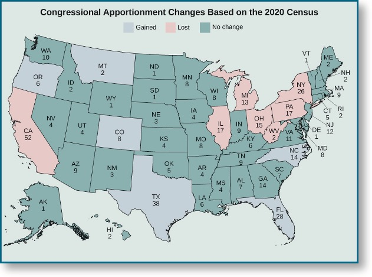

## Gerrymandering

[figure not shown]

## Gerrymandering

- *Manipulative dividing of election district boundaries to give majority advantage to one party*
- *Packing*: Cramming as many opposition voters as possible into one district
- *Cracking*: Splitting a concentrated group of opposition voters across multiple districts so they’re a minority in each one

## Gerrymandering

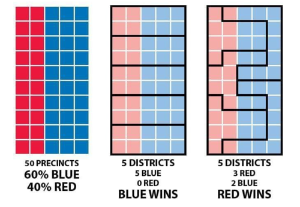

## Gerrymandering

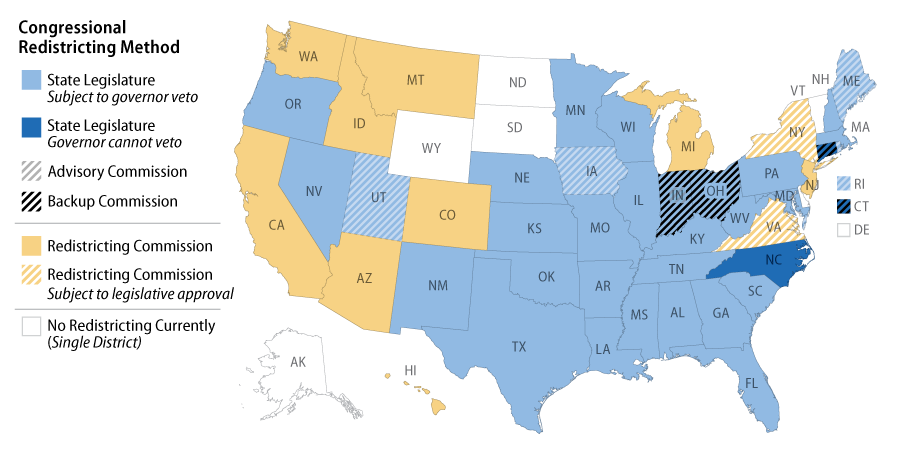

## What Counts as a Gerrymander?

- Common definition: drawing lines to give a party an *unfair* advantage — but what is “unfair”?

| State | How the map was drawn | Result |
| --- | --- | --- |
| California (2020–26) | Independent commission, no political data | Democrats: ~60% of votes, 75–83% of seats |
| Massachusetts | GOP voters spread evenly statewide | Republicans: ~40% of votes, no House seat since 1994 |
| Texas | Legislature, used political data | Republicans: ~66% of seats — a *smaller* bonus than California’s |
| Indiana | Compact, regular-looking map | Democrats: ~40% of votes, 23% of seats |

## Who Polices Gerrymandering?

- **Racial gerrymandering**: challenged in federal court under the Equal Protection Clause and the Voting Rights Act
- **Partisan gerrymandering**: *Rucho v. Common Cause* (2019) — a **nonjusticiable** political question for federal courts
- Remedies for partisan maps are left to:
  - State courts and state constitutions
  - Independent redistricting commissions
  - Congress
- Where race and party overlap, the line blurs: *Alexander v. South Carolina NAACP* (2024) lets states defend a map by claiming **partisan** intent

## Mid-Decade Redistricting

### Ahead of the 2026 Midterms

- States normally redraw congressional maps only once per decade, after the census
- Since July 2025, a wave of **mid-decade redistricting** has redrawn maps in states on both sides of the aisle
- Before 2025, only two states had voluntarily redistricted mid-decade since 1970
- By September 2026, **ten states** had new congressional maps — some voluntary, some required by law, some ordered by courts

## Mid-Decade Redistricting

### The Numbers

| State | Driver | Net Partisan Effect |
| --- | --- | --- |
| Texas | Voluntary (legislature) | +5 R |
| California | Voluntary (commission) | +5 D |
| Florida | Voluntary (legislature) | +4 R |
| Ohio | Required by state law | +2 R |
| Utah | Litigation | +1 D |
| AL, LA, MO, NC, TN | Voluntary / litigation | +1 R each |

**Net: +10 Republican-favorable seats** nationwide, as of Sept. 2026

## The Legal Trigger: *Louisiana v. Callais*

- April 2026: The Supreme Court rules Louisiana’s second majority-Black congressional district an **unconstitutional racial gerrymander**
- Builds on *Rucho v. Common Cause* (2019), which held partisan-gerrymandering claims **nonjusticiable**
- Effect: states can defend race-based challenges by pointing to partisan intent — narrowing the reach of the Voting Rights Act
- Opened the door for Alabama, Tennessee, and South Carolina to revisit maps previously constrained by VRA litigation

# Representation in the Senate

## Congressional Elections

### The Senate; Article I Section 3

- Two from each state
- Elected every six years
- Originally appointed by state legislatures
  - Seventeenth Amendment (1913)
- Must be 30 years old

## The Great Compromise

- **Virginia Plan**: representation based on population (favored large states)
- **New Jersey Plan**: equal representation for every state (favored small states)
- **Compromise**: House by population, Senate with two per state
- Madison (Fed. 62): the equal vote is “a constitutional recognition of the portion of sovereignty remaining in the individual states, and an instrument for preserving that residuary sovereignty”
- The Senate represents **states as states** — federalism

## A Double Majority

- Every law needs “a majority of the people, and then, of a majority of the states”
- Madison admits this check “may, in some instances, be injurious as well as beneficial”
- But “the facility and excess of law-making seem to be the diseases to which our governments are most liable”
- Bicameralism adds one more **veto point** — another source of the system’s bias against action

## The Seventeenth Amendment (1913)

- Framers: state legislatures choose senators — a “select appointment” and a voice for state governments
- After the Civil War, problems mounted:
  - Reporters accused legislatures of taking **bribes** to elect senators friendly to special interests
  - **Deadlocked** legislatures left states without full Senate representation for months or years
- Reformers’ answer: **direct popular election**
- The only major change to the framers’ Senate design

## Equal States, Unequal People

**Wyoming**

588,753 people

2 senators

**California**

~39.6 million people

2 senators

- A Wyoming resident has roughly **67 times** the Senate weight of a Californian
- **Defenders**: protects small states and federalism; cools majority passion
- **Critics**: “minority rule” — senators representing a minority of Americans can form a Senate majority

# Electoral Incentives

## Why Incentives Matter

- Members of Congress are rational actors who put **reelection** first
- Then *how* elections are run shapes what members do in office
- The framers balanced two goals:
  - Two-year House terms keep members **accountable**
  - Six-year Senate terms **insulate** members from “sudden and violent passions” (Fed. 62)
- Did they get the balance right for a modern Congress?

## The Never-Ending Campaign

- House members face voters every **two years**; one-third of the Senate is always up
- The U.S. sets **no limit** on how long campaigns last
  - United Kingdom: about 25 working days
  - Japan: about 12 days
- Congressional working days have declined since the mid-1990s
- Both chambers sharply cut time in Washington in election-year Octobers and Novembers

## The Rising Cost of Campaigns

Average incumbent spending (inflation-adjusted)

|  | 1986 | 2024 |
| --- | --- | --- |
| House | $1.06 million | $2.7 million |
| Senate | $9.03 million | $25.6 million |

- By some estimates, members spend more hours on donor calls than on committee and floor work combined
- Heavy reliance on large donors is associated with **fewer** bills introduced, speeches given, and hearings attended

## Primaries and Safe Seats

- Fewer than **20%** of voters cast primary ballots
- In 2022, **8%** of voters effectively decided **83%** of House races
- Primary voters skew older, whiter, and more partisan
- Competitive House districts: **164** (37.7%) in 1997 → **42** (9.7%) in 2026
- States with split-party Senate delegations: **27** in 1980 → **4** today
- In a safe seat, the only real threat is the **primary** — which rewards party loyalty over compromise

## Insecure Majorities

- 1933–1994: long stretches of one-party control of Congress
- Since the mid-1990s (House) and early 1980s (Senate): control can flip almost every election
- Every election is a fight for the majority, so party leaders:
  - Tightly control the floor agenda
  - Allow fewer amendments
  - Protect vulnerable members and stress **party unity**
- 2025: about **70%** of House votes and **94%** of Senate votes split along party lines

## Are Incentives the Whole Story?

- Electoral incentives are **one factor among several**:
  - A fragmented media environment
  - Congress’s limited staff and institutional capacity
  - Growth of unilateral executive power
- Congress still passes many **low-profile, bipartisan** bills each year
- Judging Congress requires a view of what a “well-functioning Congress” *should* do